# Analysis and Prediction of Weightlifting Competency (PML)

John C McDavid

May 1, 2016

# Objective

## Citation and reference

This anlysis is this paper uses data from the following research: Ugulino, W.; Cardador, D.; Vega, K.; Velloso, E.; Milidiu, R.; Fuks, H. Wearable Computing: Accelerometers’ Data Classification of Body Postures and Movements. Proceedings of 21st Brazilian Symposium on Artificial Intelligence. Advances in Artificial Intelligence - SBIA 2012. In: Lecture Notes in Computer Science. , pp. 52-61. Curitiba, PR: Springer Berlin / Heidelberg, 2012. ISBN 978-3-642-34458-9. DOI: 10.1007/978-3-642-34459-6_6. Read more at http://groupware.les.inf.puc-rio.br/har#ixzz47MfWwhbW.

## Approach

In this paper we will develop an algorithm to discriminate between the variosu ways the researchers had the particpants periform the weightlifting exercise. We ultimately settle on using a random forest method as the best method to develop an algorithm to meet the objective but we also explore the possibilities of using random forest with the data centered and scaled, gbm, and lda. The alternative models were all inferior or did not add appreciable accuracy.  
Cross-validation is handled internal to the caret::train function through train control.  
We also use parallel processing to help with run time.

## Data

The training and test data for the project are from:  
https://d396qusza40orc.cloudfront.net/predmachlearn/pml-training.csv  
https://d396qusza40orc.cloudfront.net/predmachlearn/pml-testing.csv

We initialize and clear the workspace, load and read in the data, and load the necessary R libaries (we assume the libararies are installed).

```r
setwd("C:\\Users\\jcmcd\\Coursera - Practical Machine Learning")
rm(list=ls())

# libraries
library(caret); library(ggplot2); library(lattice); library(rpart); library(rpart.plot)
library(doParallel); library(parallel); library(randomForest)
library(rattle); library(corrplot)
# load data
# training
fileUrl <- "https://d396qusza40orc.cloudfront.net/predmachlearn/pml-training.csv?accessType=DOWNLOAD"
download.file(fileUrl, destfile="./data/pml-train.csv")
Train <- read.csv("./data/pml-train.csv")
# testing
fileUrl <- "https://d396qusza40orc.cloudfront.net/predmachlearn/pml-testing.csv?accessType=DOWNLOAD"
download.file(fileUrl, destfile="./data/pml-test.csv")
Test <- read.csv("./data/pml-test.csv")
```

## Exploratory Analysis

We explore the dataset.

```r
unique(Train$classe)
```

```
## [1] A B C D E
## Levels: A B C D E
```

```r
dim(Train); dim(Test)
```

```
## [1] 19622   160
```

```
## [1]  20 160
```

```r
sum(Train$classe == "A")
```

```
## [1] 5580
```

```r
sum(Train$classe == "B")
```

```
## [1] 3797
```

```r
sum(Train$classe == "C")
```

```
## [1] 3422
```

```r
sum(Train$classe == "D")
```

```
## [1] 3216
```

```r
sum(Train$classe == "E")
```

```
## [1] 3607
```

```r
sum(5580, 3797, 3422, 3216, 3607)
```

```
## [1] 19622
```

```r
names(Train)
```

```
##   [1] "X"                        "user_name"
##   [3] "raw_timestamp_part_1"     "raw_timestamp_part_2"
##   [5] "cvtd_timestamp"           "new_window"
##   [7] "num_window"               "roll_belt"
##   [9] "pitch_belt"               "yaw_belt"
##  [11] "total_accel_belt"         "kurtosis_roll_belt"
##  [13] "kurtosis_picth_belt"      "kurtosis_yaw_belt"
##  [15] "skewness_roll_belt"       "skewness_roll_belt.1"
##  [17] "skewness_yaw_belt"        "max_roll_belt"
##  [19] "max_picth_belt"           "max_yaw_belt"
##  [21] "min_roll_belt"            "min_pitch_belt"
##  [23] "min_yaw_belt"             "amplitude_roll_belt"
##  [25] "amplitude_pitch_belt"     "amplitude_yaw_belt"
##  [27] "var_total_accel_belt"     "avg_roll_belt"
##  [29] "stddev_roll_belt"         "var_roll_belt"
```

[output cut: 65 more lines]

## Cleaning

We have to remove columns that have missing data and remove seven other cols (X, user name, 3 timestamps, 2 “windows”) that aren’t useful. This results in 53 remaining variables, including the outcome variable “classe.”  
We then apply the same removal to the test dataset and check to make sure there are no additional cols in the test dataset that need to be removed (there aren’t any).  
Finally, we make sure the fields in the train and test datasets are the same (except for the outcome variable in the train set and the problem_id variable in the test set.)

```r
# have to elim cols that have NA or ""
msgcols2 <- sapply(Train, function(x) any(is.na(x) | x == ""))
sum(msgcols2)
```

```
## [1] 100
```

```r
TrainCln1 <- names(msgcols2)[!msgcols2]
TrainCln2 <- TrainCln1[-c(1:7)]

Train2 <- Train[,TrainCln2]
dim(Train2)
```

```
## [1] 19622    53
```

```r
# do same clean on test, make sure nothing additional is msg in test
Test2 <- Test[,c(TrainCln2[-53],"problem_id")]
dim(Test2)
```

```
## [1] 20 53
```

```r
# [1] 20 53
msgcols2test <- sapply(Test2, function(x) any(is.na(x) | x == ""))  # ck for additional msg cols in Test
sum(msgcols2test)  # any addit'l cols w missing vals?
```

```
## [1] 0
```

```r
sum(names(Train2) == names(Test2))
```

```
## [1] 52
```

## Partitioning

We set a seed and partition the cleaned train dataset into training and testing datasets using a 70/30 split. The original test dataset is held out from the aanlysis.

```r
set.seed(526526)
inTrain <- createDataPartition(y = Train2$classe,
                               p = 0.7, list = FALSE)
TrainClnTrain <- Train2[inTrain,]
TrainClnTest <- Train2[-inTrain,]
```

## Test for near zero variance of predictors and linear combinations of cols.

```r
# test nzv nearZeroVar on training
nzv <- nearZeroVar(TrainClnTrain, saveMetrics = TRUE)
# nzv
sum(nzv[,3],nzv[,4])    # any zero or near zero variances?
```

```
## [1] 0
```

```r
# look for linear combins
findLinearCombos(Train2[,-53])
```

```
## $linearCombos
## list()
##
## $remove
## NULL
```

We now have cleaned Train2, Test2 datasets + Train2 partitioned to TrainClnTrain, TrainClnTest

```r
dim(Train2)
```

```
## [1] 19622    53
```

```r
dim(TrainClnTrain)
```

```
## [1] 13737    53
```

```r
dim(TrainClnTest)
```

```
## [1] 5885   53
```

## More Exploration

```r
cluster <- makeCluster(detectCores() - 1)    # convention is to leave 1 core for OS
registerDoParallel(cluster)

mstart <- Sys.time()
Agraph <- rpart(classe ~ ., data = TrainClnTrain, method = "class")
mend <- Sys.time()
c(mstart, mend)
```

```
## [1] "2016-05-01 22:50:37 EDT" "2016-05-01 22:50:40 EDT"
```

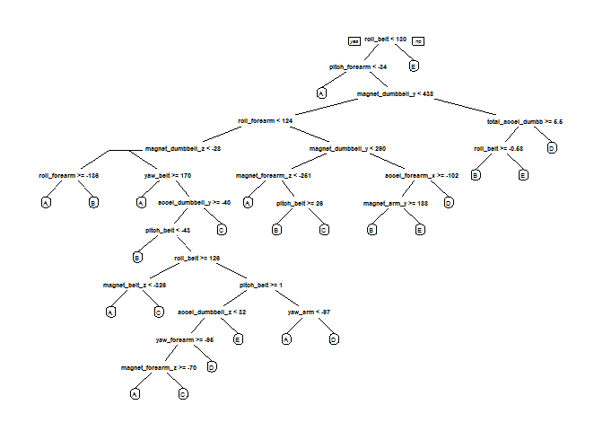

```r
stopCluster(cluster)   # de-register parallel process cluster

prp(Agraph)
```

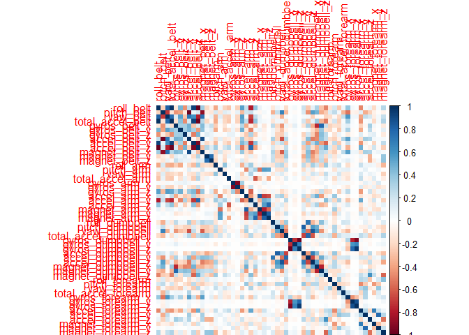

```r
# fancyRpartPlot(Agraph)      # works but tooo many bottow rows....prp more readable

cPlot <- cor(TrainClnTrain[,-53])
corrplot(cPlot, method = "color")
```

# Main Model 4.

```r
library(doParallel)
library(parallel)
cluster <- makeCluster(detectCores() - 1)    # convention is to leave 1 core for OS
registerDoParallel(cluster)

set.seed(526)
ctrl <- trainControl(method="cv", number = 10, allowParallel = TRUE)

mstart <- Sys.time()
modFit4 <- train(classe ~ ., method = "rf", data = TrainClnTrain, trControl = ctrl)
mend <- Sys.time()
c(mstart, mend)
```

```
## [1] "2016-05-01 22:50:42 EDT" "2016-05-01 23:07:55 EDT"
```

```r
stopCluster(cluster)

modFit4
```

```
## Random Forest
##
## 13737 samples
##    52 predictor
##     5 classes: 'A', 'B', 'C', 'D', 'E'
##
## No pre-processing
## Resampling: Cross-Validated (10 fold)
## Summary of sample sizes: 12363, 12361, 12365, 12363, 12362, 12363, ...
## Resampling results across tuning parameters:
##
##   mtry  Accuracy   Kappa      Accuracy SD  Kappa SD
##    2    0.9919915  0.9898685  0.001914153  0.002422719
##   27    0.9912645  0.9889491  0.002590485  0.003277818
##   52    0.9884259  0.9853582  0.002898504  0.003667845
##
## Accuracy was used to select the optimal model using  the largest value.
## The final value used for the model was mtry = 2.
```

```r
modFit4$finalModel
```

```
##
## Call:
##  randomForest(x = x, y = y, mtry = param$mtry)
##                Type of random forest: classification
##                      Number of trees: 500
## No. of variables tried at each split: 2
##
##         OOB estimate of  error rate: 0.72%
## Confusion matrix:
##      A    B    C    D    E  class.error
## A 3903    3    0    0    0 0.0007680492
## B   16 2634    8    0    0 0.0090293454
## C    0   20 2374    2    0 0.0091819699
## D    0    0   40 2211    1 0.0182060391
## E    0    1    2    6 2516 0.0035643564
```

```r
varImp(modFit4)
```

```
## rf variable importance
##
##   only 20 most important variables shown (out of 52)
##
##                   Overall
## roll_belt          100.00
## yaw_belt            79.34
## magnet_dumbbell_z   70.02
## pitch_belt          63.02
## magnet_dumbbell_y   60.95
## pitch_forearm       59.14
## roll_forearm        52.85
## magnet_dumbbell_x   52.34
## accel_belt_z        45.76
## roll_dumbbell       43.49
## accel_dumbbell_y    43.31
## magnet_belt_z       42.70
## magnet_belt_y       40.20
## accel_dumbbell_z    38.25
## roll_arm            35.82
## accel_forearm_x     32.20
## gyros_belt_z        32.09
## yaw_dumbbell        29.61
## accel_dumbbell_x    29.28
## gyros_dumbbell_y    28.72
```

```r
# order(varImp(modFit4), decreasing = T)

varImp(modFit4, scale = "TRUE")
```

```
## rf variable importance
##
##   only 20 most important variables shown (out of 52)
##
##                   Overall
## roll_belt          100.00
## yaw_belt            79.34
## magnet_dumbbell_z   70.02
## pitch_belt          63.02
## magnet_dumbbell_y   60.95
## pitch_forearm       59.14
## roll_forearm        52.85
## magnet_dumbbell_x   52.34
## accel_belt_z        45.76
## roll_dumbbell       43.49
## accel_dumbbell_y    43.31
## magnet_belt_z       42.70
## magnet_belt_y       40.20
## accel_dumbbell_z    38.25
## roll_arm            35.82
## accel_forearm_x     32.20
## gyros_belt_z        32.09
## yaw_dumbbell        29.61
## accel_dumbbell_x    29.28
## gyros_dumbbell_y    28.72
```

```r
# order(varImp(modFit4), decreasing = T)

# plot tree

# predict on trainclntest
pred.modFit4 <- predict(modFit4, TrainClnTest)
confusionMatrix(TrainClnTest$classe, pred.modFit4)
```

```
## Confusion Matrix and Statistics
##
##           Reference
## Prediction    A    B    C    D    E
##          A 1673    1    0    0    0
##          B    4 1133    2    0    0
##          C    0    8 1016    2    0
##          D    0    0   20  944    0
##          E    0    0    0    2 1080
##
## Overall Statistics
##
##                Accuracy : 0.9934
##                  95% CI : (0.991, 0.9953)
##     No Information Rate : 0.285
##     P-Value [Acc > NIR] : < 2.2e-16
##
##                   Kappa : 0.9916
##  Mcnemar's Test P-Value : NA
##
## Statistics by Class:
##
##                      Class: A Class: B Class: C Class: D Class: E
## Sensitivity            0.9976   0.9921   0.9788   0.9958   1.0000
## Specificity            0.9998   0.9987   0.9979   0.9959   0.9996
## Pos Pred Value         0.9994   0.9947   0.9903   0.9793   0.9982
## Neg Pred Value         0.9991   0.9981   0.9955   0.9992   1.0000
## Prevalence             0.2850   0.1941   0.1764   0.1611   0.1835
## Detection Rate         0.2843   0.1925   0.1726   0.1604   0.1835
## Detection Prevalence   0.2845   0.1935   0.1743   0.1638   0.1839
## Balanced Accuracy      0.9987   0.9954   0.9884   0.9959   0.9998
```

```r
Accuracy <- postResample(pred.modFit4, TrainClnTest$classe)
Accuracy
```

```
##  Accuracy     Kappa
## 0.9933730 0.9916167
```

```r
# out of sample error is 1 - Accuracy on testing set
1- Accuracy
```

```
##    Accuracy       Kappa
## 0.006627018 0.008383262
```

```r
# report noth oob and traincln test err rate???

# now predict on Test set fron original download ....P
pred.modFit4Test <- predict(modFit4, Test2)
pred.modFit4Test
```

```
##  [1] B A B A A E D B A A B C B A E E A B B B
## Levels: A B C D E
```

```r
# end 4 ...works
```

Graphing:

```r
# 4.1.2 for graphing

cluster <- makeCluster(detectCores() - 1)    # convention is to leave 1 core for OS
registerDoParallel(cluster)

mstart <- Sys.time()
Agraph <- rpart(classe ~ ., data = TrainClnTrain, method = "class")
mend <- Sys.time()
c(mstart, mend)
```

```
## [1] "2016-05-01 23:07:57 EDT" "2016-05-01 23:07:59 EDT"
```

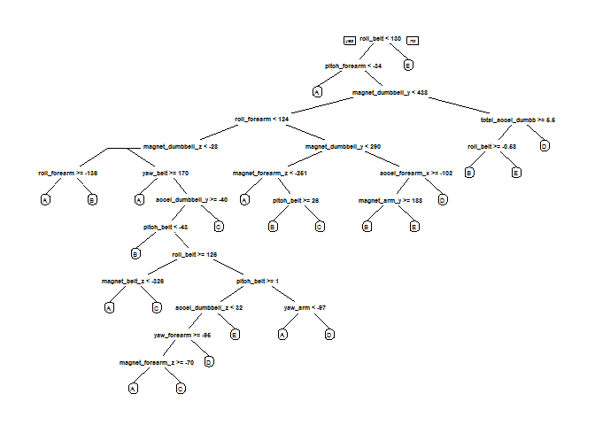

```r
stopCluster(cluster)   # de-register parallel process cluster


prp(Agraph)     # works
```

[figure not shown]

```r
fancyRpartPlot(Agraph)      # works but tooo many bottow rows....prp more readable
```

## Results/Conclusions

The random forest model with internal cross validation proved to be teh most accurate model of all the model types tested. The predictions made on the test dataset are reported above.

## Model Alternatives

### GBM model

This model is not as good as the chosen random forest model; the out of sample error rate is 4%.

```r
# -------------------------
# 4.2 w gbm (c/p from 4 w modif)
library(doParallel)
library(parallel)
cluster <- makeCluster(detectCores() - 1)    # convention is to leave 1 core for OS
registerDoParallel(cluster)

set.seed(526)
ctrl <- trainControl(method="cv", number = 10, allowParallel = TRUE)

mstart <- Sys.time()
modFit4.2 <- train(classe ~ ., method = "gbm", data = TrainClnTrain, trControl = ctrl)    # method gbm
mend <- Sys.time()
#
stopCluster(cluster)
c(mstart, mend)
```

```
## [1] "2016-05-01 23:08:02 EDT" "2016-05-01 23:13:31 EDT"
```

```r
modFit4.2
```

```
## Stochastic Gradient Boosting
##
## 13737 samples
##    52 predictor
##     5 classes: 'A', 'B', 'C', 'D', 'E'
##
## No pre-processing
## Resampling: Cross-Validated (10 fold)
## Summary of sample sizes: 12363, 12361, 12365, 12363, 12362, 12363, ...
## Resampling results across tuning parameters:
##
##   interaction.depth  n.trees  Accuracy   Kappa      Accuracy SD
##   1                   50      0.7553998  0.6899370  0.013111832
##   1                  100      0.8210647  0.7734430  0.011702037
##   1                  150      0.8541860  0.8153523  0.009987297
##   2                   50      0.8546992  0.8158076  0.009902794
##   2                  100      0.9071859  0.8825414  0.008108452
##   2                  150      0.9322272  0.9142251  0.006800047
##   3                   50      0.8946610  0.8666288  0.008316264
##   3                  100      0.9429254  0.9277652  0.005435254
##   3                  150      0.9616352  0.9514571  0.004014674
##   Kappa SD
##   0.016773138
##   0.014878579
##   0.012719421
##   0.012632308
##   0.010294598
##   0.008648046
##   0.010613669
##   0.006907220
##   0.005096266
##
## Tuning parameter 'shrinkage' was held constant at a value of 0.1
##
## Tuning parameter 'n.minobsinnode' was held constant at a value of 10
## Accuracy was used to select the optimal model using  the largest value.
## The final values used for the model were n.trees = 150,
##  interaction.depth = 3, shrinkage = 0.1 and n.minobsinnode = 10.
```

```r
modFit4.2$finalModel
```

```
## A gradient boosted model with multinomial loss function.
## 150 iterations were performed.
## There were 52 predictors of which 44 had non-zero influence.
```

```r
postResample(predict(modFit4.2,TrainClnTrain),TrainClnTrain$classe)
```

```
##  Accuracy     Kappa
## 0.9736478 0.9666614
```

```r
varImp(modFit4.2)
```

```
## gbm variable importance
##
##   only 20 most important variables shown (out of 52)
##
##                   Overall
## roll_belt         100.000
## pitch_forearm      50.563
## yaw_belt           38.251
## magnet_dumbbell_z  33.907
## roll_forearm       23.891
## magnet_belt_z      23.267
## magnet_dumbbell_y  22.965
## roll_dumbbell      16.978
## gyros_belt_z       15.383
## accel_forearm_x    11.997
## pitch_belt         11.128
## accel_forearm_z    10.846
## gyros_dumbbell_y   10.118
## accel_dumbbell_x    8.275
## yaw_arm             7.652
## accel_dumbbell_y    7.644
## magnet_forearm_z    7.322
## magnet_arm_z        7.282
## magnet_belt_x       5.100
## roll_arm            5.079
```

```r
# order(varImp(modFit4.2), decreasing = T)

varImp(modFit4.2, scale = "TRUE")
```

```
## gbm variable importance
##
##   only 20 most important variables shown (out of 52)
##
##                   Overall
## roll_belt         100.000
## pitch_forearm      50.563
## yaw_belt           38.251
## magnet_dumbbell_z  33.907
## roll_forearm       23.891
## magnet_belt_z      23.267
## magnet_dumbbell_y  22.965
## roll_dumbbell      16.978
## gyros_belt_z       15.383
## accel_forearm_x    11.997
## pitch_belt         11.128
## accel_forearm_z    10.846
## gyros_dumbbell_y   10.118
## accel_dumbbell_x    8.275
## yaw_arm             7.652
## accel_dumbbell_y    7.644
## magnet_forearm_z    7.322
## magnet_arm_z        7.282
## magnet_belt_x       5.100
## roll_arm            5.079
```

```r
# order(varImp(modFit4.2), decreasing = T)

# predict on trainclntest
pred.modFit4.2 <- predict(modFit4.2, TrainClnTest)
confusionMatrix(TrainClnTest$classe, pred.modFit4.2)
```

```
## Confusion Matrix and Statistics
##
##           Reference
## Prediction    A    B    C    D    E
##          A 1651   12    7    4    0
##          B   49 1056   34    0    0
##          C    0   29  986    9    2
##          D    0    2   45  912    5
##          E    2   10    9   20 1041
##
## Overall Statistics
##
##                Accuracy : 0.9594
##                  95% CI : (0.954, 0.9643)
##     No Information Rate : 0.2892
##     P-Value [Acc > NIR] : < 2.2e-16
##
##                   Kappa : 0.9486
##  Mcnemar's Test P-Value : 4.567e-14
##
## Statistics by Class:
##
##                      Class: A Class: B Class: C Class: D Class: E
## Sensitivity            0.9700   0.9522   0.9121   0.9651   0.9933
## Specificity            0.9945   0.9826   0.9917   0.9895   0.9915
## Pos Pred Value         0.9863   0.9271   0.9610   0.9461   0.9621
## Neg Pred Value         0.9879   0.9888   0.9804   0.9933   0.9985
## Prevalence             0.2892   0.1884   0.1837   0.1606   0.1781
## Detection Rate         0.2805   0.1794   0.1675   0.1550   0.1769
## Detection Prevalence   0.2845   0.1935   0.1743   0.1638   0.1839
## Balanced Accuracy      0.9823   0.9674   0.9519   0.9773   0.9924
```

```r
Accuracy <- postResample(pred.modFit4.2, TrainClnTest$classe)
Accuracy
```

```
##  Accuracy     Kappa
## 0.9593883 0.9486053
```

```r
# out of sample error is 1 - Accuracy on testing set
1- Accuracy
```

```
##   Accuracy      Kappa
## 0.04061172 0.05139474
```

```r
# now predict on Test set fron original download ....P
pred.modFit4.2Test <- predict(modFit4.2, Test2)
pred.modFit4.2Test
```

```
##  [1] B A B A A E D B A A B C B A E E A B B B
## Levels: A B C D E
```

```r
# end 4.2
# -------------------------
```

### lda model:

The linear discriminate analysis model is awful and all characteristics make it a vastly inferior model (out of sample error rate is 29%).

```r
# 4.3 lda
library(doParallel)
library(parallel)
cluster <- makeCluster(detectCores() - 1)    # convention is to leave 1 core for OS
registerDoParallel(cluster)

set.seed(526)
ctrl <- trainControl(method="cv", number = 10, allowParallel = TRUE)

mstart <- Sys.time()
modFit4.3 <- train(classe ~ ., method = "lda", data = TrainClnTrain, trControl = ctrl)    # method lda
mend <- Sys.time()
#
stopCluster(cluster)
c(mstart, mend)
```

```
## [1] "2016-05-01 23:13:32 EDT" "2016-05-01 23:13:44 EDT"
```

```r
modFit4.3
```

```
## Linear Discriminant Analysis
##
## 13737 samples
##    52 predictor
##     5 classes: 'A', 'B', 'C', 'D', 'E'
##
## No pre-processing
## Resampling: Cross-Validated (10 fold)
## Summary of sample sizes: 12363, 12361, 12365, 12363, 12362, 12363, ...
## Resampling results
##
##   Accuracy  Kappa      Accuracy SD  Kappa SD
##   0.700154  0.6205345  0.009059321  0.01122097
##
##
```

```r
# modFit4.3$finalModel

postResample(predict(modFit4.3,TrainClnTrain),TrainClnTrain$classe)
```

```
##  Accuracy     Kappa
## 0.7048118 0.6263789
```

```r
# predict on trainclntest
pred.modFit4.3 <- predict(modFit4.3, TrainClnTest)
confusionMatrix(TrainClnTest$classe, pred.modFit4.3)
```

```
## Confusion Matrix and Statistics
##
##           Reference
## Prediction    A    B    C    D    E
##          A 1366   35  129  136    8
##          B  168  756  120   40   55
##          C  108   89  683  113   33
##          D   50   47  104  718   45
##          E   39  184   98   99  662
##
## Overall Statistics
##
##                Accuracy : 0.7111
##                  95% CI : (0.6994, 0.7227)
##     No Information Rate : 0.2941
##     P-Value [Acc > NIR] : < 2.2e-16
##
##                   Kappa : 0.6345
##  Mcnemar's Test P-Value : < 2.2e-16
##
## Statistics by Class:
##
##                      Class: A Class: B Class: C Class: D Class: E
## Sensitivity            0.7891   0.6805   0.6023   0.6492   0.8244
## Specificity            0.9259   0.9198   0.9278   0.9485   0.9174
## Pos Pred Value         0.8160   0.6637   0.6657   0.7448   0.6118
## Neg Pred Value         0.9133   0.9252   0.9072   0.9212   0.9706
## Prevalence             0.2941   0.1888   0.1927   0.1879   0.1364
## Detection Rate         0.2321   0.1285   0.1161   0.1220   0.1125
## Detection Prevalence   0.2845   0.1935   0.1743   0.1638   0.1839
## Balanced Accuracy      0.8575   0.8001   0.7650   0.7989   0.8709
```

```r
Accuracy <- postResample(pred.modFit4.3, TrainClnTest$classe)
Accuracy
```

```
##  Accuracy     Kappa
## 0.7111300 0.6344933
```

```r
# out of sample error is 1 - Accuracy on testing set
1- Accuracy
```

```
##  Accuracy     Kappa
## 0.2888700 0.3655067
```

```r
# --> 28.89%

# now predict on Test set fron original download ....P
pred.modFit4.3Test <- predict(modFit4.3, Test2)
pred.modFit4.3Test
```

```
##  [1] B A B C C C D D A A D A B A E A A B B B
## Levels: A B C D E
```

```r
# end 4.3

# -------------------------
```

## rf model 4.1 with preprocess Ctr, Scale

```r
library(doParallel)
library(parallel)
cluster <- makeCluster(detectCores() - 1)    # convention is to leave 1 core for OS
registerDoParallel(cluster)

set.seed(526)
ctrl <- trainControl(method="cv", number = 10, allowParallel = TRUE)
mstart <- Sys.time()
modFit4.1 <- train(classe ~ ., method = "rf", data = TrainClnTrain, preProcess=c("center", "scale"), trControl = ctrl)
mend <- Sys.time()
c(mstart, mend)
```

```
## [1] "2016-05-01 23:13:45 EDT" "2016-05-01 23:32:16 EDT"
```

```r
stopCluster(cluster)   # de-register parallel process cluster

modFit4.1
```

```
## Random Forest
##
## 13737 samples
##    52 predictor
##     5 classes: 'A', 'B', 'C', 'D', 'E'
##
## Pre-processing: centered (52), scaled (52)
## Resampling: Cross-Validated (10 fold)
## Summary of sample sizes: 12363, 12361, 12365, 12363, 12362, 12363, ...
## Resampling results across tuning parameters:
##
##   mtry  Accuracy   Kappa      Accuracy SD  Kappa SD
##    2    0.9917007  0.9895005  0.002282888  0.002889737
##   27    0.9913371  0.9890414  0.002413338  0.003052619
##   52    0.9882808  0.9851739  0.003187619  0.004033552
##
## Accuracy was used to select the optimal model using  the largest value.
## The final value used for the model was mtry = 2.
```

```r
modFit4.1$finalModel
```

```
##
## Call:
##  randomForest(x = x, y = y, mtry = param$mtry)
##                Type of random forest: classification
##                      Number of trees: 500
## No. of variables tried at each split: 2
##
##         OOB estimate of  error rate: 0.75%
## Confusion matrix:
##      A    B    C    D    E class.error
## A 3902    4    0    0    0 0.001024066
## B   17 2633    8    0    0 0.009405568
## C    0   20 2373    3    0 0.009599332
## D    0    0   40 2210    2 0.018650089
## E    0    0    3    6 2516 0.003564356
```

```r
# predict on TrainClnTest
pred.modFit4.1 <- predict(modFit4.1, TrainClnTest)
confusionMatrix(TrainClnTest$classe, pred.modFit4.1)
```

```
## Confusion Matrix and Statistics
##
##           Reference
## Prediction    A    B    C    D    E
##          A 1671    3    0    0    0
##          B    4 1133    2    0    0
##          C    0    8 1016    2    0
##          D    0    0   20  944    0
##          E    0    0    0    2 1080
##
## Overall Statistics
##
##                Accuracy : 0.993
##                  95% CI : (0.9906, 0.995)
##     No Information Rate : 0.2846
##     P-Value [Acc > NIR] : < 2.2e-16
##
##                   Kappa : 0.9912
##  Mcnemar's Test P-Value : NA
##
## Statistics by Class:
##
##                      Class: A Class: B Class: C Class: D Class: E
## Sensitivity            0.9976   0.9904   0.9788   0.9958   1.0000
## Specificity            0.9993   0.9987   0.9979   0.9959   0.9996
## Pos Pred Value         0.9982   0.9947   0.9903   0.9793   0.9982
## Neg Pred Value         0.9991   0.9977   0.9955   0.9992   1.0000
## Prevalence             0.2846   0.1944   0.1764   0.1611   0.1835
## Detection Rate         0.2839   0.1925   0.1726   0.1604   0.1835
## Detection Prevalence   0.2845   0.1935   0.1743   0.1638   0.1839
## Balanced Accuracy      0.9984   0.9946   0.9884   0.9959   0.9998
```

```r
Accuracy <- postResample(pred.modFit4.1, TrainClnTest$classe)
Accuracy
```

```
##  Accuracy     Kappa
## 0.9930331 0.9911872
```

```r
# out of sample error is 1 - Accuracy on testing set
1- Accuracy
```

```
##    Accuracy       Kappa
## 0.006966865 0.008812828
```

```r
# error went from .71% up to .75%
pred.modFit4.1Test <- predict(modFit4.1, Test2)
pred.modFit4.1Test
```

```
##  [1] B A B A A E D B A A B C B A E E A B B B
## Levels: A B C D E
```

```r
# end 4.1
# -------------------------
```

## 4.1.1 rf model with centering and scaling done a different way…results are the same

Comments are the same as above.

```r
library(doParallel)
library(parallel)
cluster <- makeCluster(detectCores() - 1)    # convention is to leave 1 core for OS
registerDoParallel(cluster)

set.seed(526)
ctrl <- trainControl(method="cv", number = 10, allowParallel = TRUE)
preObj <- preProcess(TrainClnTrain[,-53], method = c("center", "scale"))    # step 1
TrainClnTrain.cs <- predict(preObj, TrainClnTrain)                          # step 2a
mstart <- Sys.time()
modFit4.1.1 <- train(classe ~ ., method = "rf", data = TrainClnTrain.cs, trControl = ctrl)    # step 3
mend <- Sys.time()

stopCluster(cluster)   # de-register parallel process cluster
c(mstart, mend)
```

```
## [1] "2016-05-01 23:32:19 EDT" "2016-05-01 23:49:47 EDT"
```

```r
TrainClnTest.cs <- predict(preObj, TrainClnTest)                            # step 2b1
Test2.cs <- predict(preObj, Test2)                                          # step 2b2

modFit4.1.1
```

```
## Random Forest
##
## 13737 samples
##    52 predictor
##     5 classes: 'A', 'B', 'C', 'D', 'E'
##
## No pre-processing
## Resampling: Cross-Validated (10 fold)
## Summary of sample sizes: 12363, 12361, 12365, 12363, 12362, 12363, ...
## Resampling results across tuning parameters:
##
##   mtry  Accuracy   Kappa      Accuracy SD  Kappa SD
##    2    0.9915550  0.9893161  0.002231228  0.002823904
##   27    0.9917741  0.9895941  0.002328184  0.002945096
##   52    0.9878442  0.9846216  0.003178904  0.004022671
##
## Accuracy was used to select the optimal model using  the largest value.
## The final value used for the model was mtry = 27.
```

```r
modFit4.1.1$finalModel
```

```
##
## Call:
##  randomForest(x = x, y = y, mtry = param$mtry)
##                Type of random forest: classification
##                      Number of trees: 500
## No. of variables tried at each split: 27
##
##         OOB estimate of  error rate: 0.82%
## Confusion matrix:
##      A    B    C    D    E class.error
## A 3901    4    0    0    1 0.001280082
## B   19 2628   11    0    0 0.011286682
## C    0   14 2374    8    0 0.009181970
## D    0    1   36 2212    3 0.017761989
## E    0    2    4    9 2510 0.005940594
```

```r
# similar, sl lower err rate

# predict on TrainClnTest.cs
pred.modFit4.1.1 <- predict(modFit4.1.1, TrainClnTest.cs)
confusionMatrix(TrainClnTest.cs$classe, pred.modFit4.1.1)
```

```
## Confusion Matrix and Statistics
##
##           Reference
## Prediction    A    B    C    D    E
##          A 1673    1    0    0    0
##          B    8 1128    3    0    0
##          C    0    6 1016    4    0
##          D    0    0   11  953    0
##          E    0    0    2    2 1078
##
## Overall Statistics
##
##                Accuracy : 0.9937
##                  95% CI : (0.9913, 0.9956)
##     No Information Rate : 0.2856
##     P-Value [Acc > NIR] : < 2.2e-16
##
##                   Kappa : 0.992
##  Mcnemar's Test P-Value : NA
##
## Statistics by Class:
##
##                      Class: A Class: B Class: C Class: D Class: E
## Sensitivity            0.9952   0.9938   0.9845   0.9937   1.0000
## Specificity            0.9998   0.9977   0.9979   0.9978   0.9992
## Pos Pred Value         0.9994   0.9903   0.9903   0.9886   0.9963
## Neg Pred Value         0.9981   0.9985   0.9967   0.9988   1.0000
## Prevalence             0.2856   0.1929   0.1754   0.1630   0.1832
## Detection Rate         0.2843   0.1917   0.1726   0.1619   0.1832
## Detection Prevalence   0.2845   0.1935   0.1743   0.1638   0.1839
## Balanced Accuracy      0.9975   0.9958   0.9912   0.9958   0.9996
```

```r
Accuracy <- postResample(pred.modFit4.1.1, TrainClnTest.cs$classe)
Accuracy
```

```
##  Accuracy     Kappa
## 0.9937128 0.9920464
```

```r
#  acurr is same, kappa diff in last dec

# out of sample error is 1 - Accuracy on testing set
1- Accuracy
```

```
##    Accuracy       Kappa
## 0.006287171 0.007953643
```

```r
# error .75%
pred.modFit4.1.1Test.cs <- predict(modFit4.1.1, Test2.cs)
pred.modFit4.1.1Test.cs
```

```
##  [1] B A B A A E D B A A B C B A E E A B B B
## Levels: A B C D E
```

```r
# end 4.1.1
# -------------------------
```

# End Report

```r
Sys.time()
```

```
## [1] "2016-05-01 23:49:47 EDT"
```